# Presidential Elections: 1.8

Sono Shah

2017-08-24

# Class plan

- Tuesday: Work on final, you will turn in your progress for a grade
- Thursday: No Lecture, Lab + Stephanie will stick around lab for extra hour for help

# Can we fix it?

- Difference between uninformed and being misinformed
- Which one is easer to deal with?
- Is it possible to correct misinformation?

# Expectations

- Political beliefs about controversial factual questions in politics are often closely linked with one’s ideological preferences or partisan beliefs
- Reactions to corrective information will be influenced by those preferences

# Expectations

- Example: We expect that liberals will welcome corrective information that reinforces liberal beliefs or is consistent with a liberal worldview and will disparage information that undercuts their beliefs or worldview (and likewise for conservatives)

# Information processing

- *biased search process* : seeking out information that supports their preconceptions and avoiding evidence that undercuts their beliefs (Taber & Lodge 2006)
- *Backfire effect* : people counter argue preference-incongruent information and bolster their preexisting views

# Information processing

- The effectiveness of corrective information is therefore likely to vary depending on the extent to which the individual has been exposed to similar messages elsewhere.
- As a certain belief becomes widely viewed as discredited among the public and the press, individuals who might be ideologically sympathetic to that belief will be more likely to abandon it when exposed to corrective information.

# Research Design

- 4 Experiments
- subjects read mock newspaper articles containing a statement from a political figure that reinforces a widespread misperception.
- participants were randomly assigned to read articles that either included or did not include corrective information immediately.
- asked to answer a series of factual and opinion questions

# Issues

- war in Iraq
- tax cuts
- stem cell research

# Issues

- The existence of Iraqi WMD and the effect of the Bush tax cuts on revenue = misperceptions are contradicted by the best available evidence
- The belief that President Bush “banned” stem cell research = misperception is demonstrably incorrect.

# WMDs: effect of correction treatment

- More knowledgeable subjects **were less likely** to agree that Iraq had WMD and conservatives were **more likely** to agree with the statement.
- We also find that correction treatment did not reduce overall misperceptions and the mortality salience manipulation was statistically insignificant.

# WMDs II

- Effect of correction moderated by political views
- For very liberal subjects, the correction worked as expected, making them more likely to disagree with the statement that Iraq had WMD compared with controls.
- THe effect **backfired** for individuals who placed themselves on the right of center ideologically.
- conservatives who received a correction telling them that Iraq did not have WMD were more likely to believe that Iraq had WMD than those in the control condition.

# Explanations?

- Source credibility
- If subjects simply distrusted the media, they should simply ignore the corrective information. Instead, however, conservatives were found to have moved in the “wrong” direction – a reaction that is hard to attribute to simple distrust

# WMDs: Study II

- correction fails to reduce misperceptions
- BUT, the ideological effect is gone
- After controlling for issue importance, the effect returns

# Tax Cuts

- The second experiment in Study 2 tests subjects’ responses to the claim that President Bush’s tax cuts stimulated so much economic growth that they actually has the effect of increasing government revenue over what it would otherwise have been.

# Tax Cuts

- Overwhelming consensus among professional economists is that this claim is empirically implausible in the U.S. context

# Tax Cuts

- Conservatives are more likely to believe that tax cuts increase government revenue and more knowledgeable subjects are less likely to do so
- More importantly, the correction again fails to cause a statistically significant decline in overall misperceptions.

# Tax Cuts

- conservatives who received the treatment were significantly more likely to agree with the statement that tax cuts increased revenue than conservatives in the non-correction condition.

# Findings

- Responses to corrections in mock news articles differ significantly according to subjects’ ideological views.
- Corrections fail to reduce misperceptions for the most committed participants.
- They actually strengthen misperceptions among ideological subgroups in several cases.

# Stem Cells:

- Many liberals hold a misperception about the existence of a “ban” on stem cell research, a claim that both Senator John Kerry and Senator John Edwards made during the 2004 presidential campaign.
- In fact, while President Bush limited federal funding of stem cell research to stem cell lines created before August 2001, he did not place any limitations on privately funded research (Fournier 2004).

# Stem Cells

- We find a negative overall correction effect indicating that subjects who received the correction were less likely to believe that Bush banned stem cell research.
- We also find that subjects with more political knowledge were less likely to agree that a ban existed

# Stem cells

-In other words, while we do not find a backfire effect, the effect of the correction is again neutralized for the relevant ideological subgroup (liberals)

# Motivated reasoning

- Direct factual contradictions can actually **strengthen** ideologically grounded factual beliefs.

Do Facts matter?

# What we want:

- Ideally we want knowing + using correct information

# Knowing but ignoring correct info

- people smoke despite their knowledge of cancer or buy gas-guzzling SUVs despite their awareness of global warming.

# Believing and using incorrect information

- as when voters oppose the Affordable Care Act because they incorrectly believe that it establishes “death panels.”

# Using incorrect knowledge

- Child vaccinations
- Using misinformation that derives from the **failure** to accept an almost uniform set of elite messages also endangers people in a democratic polity.

# Vaccinations

https://youtu.be/7VG_s2PCH_c

# Vaccinations

- Despite scientists’ consensus that there is no connection between autism and vaccination against measles, mumps, and rubella (MMR), a large and growing number of communities in the United States have immunization rates well below 95 percent
- measles out breaks, 20013,14,16,17

# Vaccinations

- Case studies of school districts and some (although not all) systematic evidence suggest that parents who resist vaccination are disproportionately well off and often politically liberal.
- In a 2009 Pew survey on parental choice, respondents with at least some college education and relatively high incomes were more likely to endorse choice than those with a high school education or less or the poor.

# Vaccinations

- 2010 nonblack parents were significantly more likely to follow an alternative schedule (no other parental characteristics attained statistical significance in the multivariate model), and parents with higher incomes were more likely to hold antivaccination beliefs

# Link with partisanship/ideology

- Opposition stems largely from mistrust of the federal government and large corporations—a position occupied by both libertarians and some liberals

-people who hold and act on misinformation about childhood vaccination may be liberal, conservative, or libertarian, but they are united in their rejection of medical expertise on this topic and in their apparent indifference to the links between acting on misinformation and children’s deaths.

# Asymmetries

- Inertia is more likely than change—for people in any category
- Actors who focus on the inactive informed have the goal of moving people out of that category (into the active informed), whereas actors who focus on the active misinformed have the easier task of encouraging people to remain as they are

# Asymmetries

- politicians’ incentives to keep people misinformed but active tend to be much more powerful than (other) politicians’ incentives to try to move people away from using falsehoods into using facts

# Inertia over change

- although many americans accept scientists’ concurrence on the certainty and momentum of human-induced global warming, their support for government action beyond encouraging companies to save energy and individuals to recycle news- papers remains stably low to moderate.

# Politician’s incentives

- parties in campaign mode (are there any other modes?) not only seek to induce supporters who are already informed and active to vote and contribute time or money but also try strenuously to mobilize copartisans who are informed but inactive
- they already endorse the party’s candidate but need to be hunted down so that they will act on their knowledge by contributing or voting

# Politican’s incentives

- persuasion directed at people whose views are in tension with their actions can motivate some to reduce that dissonance by moving from inactivity to the active use of valid information

# Other side?

- Working to persuade the active misinformed to attain and use correct factual knowledge

# Other side?

- since the active misinformed unite their purported knowledge and their political actions, they have little incentive to abandon old beliefs, accept new ones, abandon old allegiances, find a new group, and change their behavior.

# Other side?

- So party activists largely ignore the active misinformed who support their opponents and instead concentrate on keeping their own supporters, regardless of whether they are misinformed, politically active

# Obama Birthers

- where Obama was born is not genuinely in dispute or subject to alternative interpretations.
- Thirteen Republican members of Congress cosponsored a bill in 2009 requiring presidential candidates to “include within the [campaign] committee’s statement of organization a copy of the candidate’s birth certificate” along with appropriate documentation

# Obama Birthers

- In 2011, legislators in 17 states filed bills requiring presidential candidates to prove their constitutional citizenship before being allowed onto a state ballot.

# Politician statements:

> it’s not for me to state [whether the president is a native-born citizen or a Christian]. That’s for the president to state. . . . I think we should take the president at his word - Michele Bachmann

> I would love to know more. What I know is troubling enough - Mike Huckabee

# The public

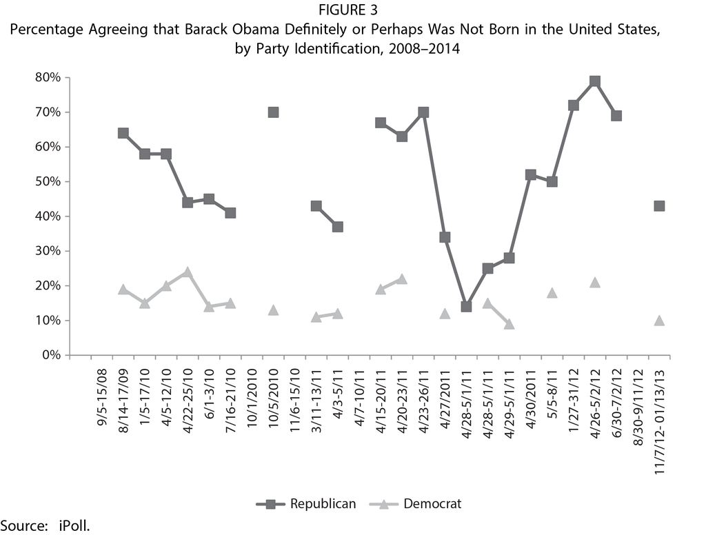

# Birthier

- A substantial proportion of Republicans agreed that Obama was born outside the United States or were uncertain or unwilling to venture an opinion.

# Political reality

> many americans are wrong about this state of affairs, link it to their partisan identity, are emotionally invested in their position, and have been encouraged to maintain this stance by partisan elites

# Why is this dangerous?

- Birtherism wastes scarce resources of energy for and attention to politics.
- Birtherism is also harmful, as well as irresistible to some politicians, because it stokes citizens’ ineffective frustration with contemporary American politics.

# Why is this dangerous?

- 2012 ANES: 58 percent of those who accepted Obama’s native-born status were highly mistrustful of the federal gov.
- 73 percent of those who rejected his native-born status also rejected the government.

# Why is this dangerous?

- Birtherism may tempt politicians as a respectable vehicle for reinforcing some individuals’ view that Obama’s race or foreign ancestry pushes him out of the legitimate American mainstream

# Why is this dangerous?

In the 2010 Evaluations of Government and Society Survey (part of the ANES), even with controls for party identification and ideology, racial resentment was positively related to whites’ doubts about Obama’s American birth.

# Incentives exist

In short, politicians flirt with birtherism and thereby encourage people to maintain belief in and act on false statements of fact for several reasons—to be witty, to distract voters from more difficult issues, to reinforce hatred of government, and to promote hostility to Obama and all that he personifies.

# Asymmetry III

politicians’ incentives to keep people acting on misinformation are almost always greater than (other) politicians’ incentives to move those individuals into the Jeffersonian ideal or even into inactivity.

# Thought experiment

- Assume for the sake of argument that political elites know that the active misinformed are indeed mistaken and are acting on their misapprehensions politically—thus probably working against their own true interests or against the interests of the polity as a whole

# Actions

- to encourage people to remain misinformed
- to ignore the dangers of actively using misinformation and worth with people wherever they are
- to try to move people into the ranks of the active informed